## Course: Visual Analytics for Policy and Management

### Univariate Exercise 1

#### Figures:

1. Ordered Bar Plot using ggplot
2. Loliplot
3. Box Plot
4. Histogram
5. Histogram and Density Plot using ggplot

#### Exercise 1 - Ordered Bar Plot

Loading data to be used and libraries:

```r
link='https://github.com/EvansDataScience/VisualAnalytics_2_tabularData/raw/master/data/eduwa.rda'

load(file=url(link))

library(ggplot2)
```

Create a table with the proportions and multiply by 100 to get percentages

```r
absoluteT=table(eduwa$LocaleType,exclude = 'nothing')
ToPlot=prop.table(absoluteT)
names(ToPlot)[5]='Unknown'
ToPlot=ToPlot*100
paste0(round(ToPlot,2),'%')
```

```
## [1] "29.42%" "20.81%" "32.88%" "13.93%" "2.97%"
```

Create an ordered dataframe for ggplot to plot. “Locale”, our categorical variable is not ordered so we can rearange it.

```r
OrderedToPlot=sort(ToPlot) #first ordering the table
tableFreq=as.data.frame(OrderedToPlot) #save the ordered table as a data frame
names(tableFreq)=c("locale","pct") # label vars

tableFreq
```

```
##    locale       pct
## 1 Unknown  2.966625
## 2    Town 13.926658
## 3   Rural 20.807581
## 4    City 29.419036
## 5  Suburb 32.880099
```

Misc plot elements like title and source:

```r
titleText='Are all locations getting a fair share of public schools in WA?'
sourceText='Source: US Department of Education'
```

Create Plot

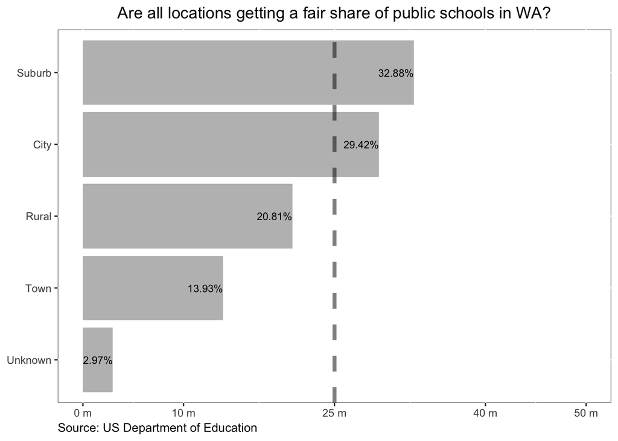

```r
base= ggplot(data = tableFreq,
             aes(x = locale,
                 y = pct))

plot1 = base + geom_bar(fill ="gray",
                        stat = 'identity')
plot2 = plot1 + labs(title=titleText,
                     x =NULL,
                     y = NULL,
                     caption = sourceText)
plot3 = plot2 + geom_hline(yintercept = 25,
                           linetype="dashed",
                           size=1.5,
                           alpha=0.5)

plot4 = plot3 + scale_y_continuous(breaks=c(0,10, 25,40,50),
                                 limits = c(0, 50),
                                 labels=scales::unit_format(suffix = '%'))

plot5 = plot4 + theme(panel.background = element_rect(fill = "white",
                                                    colour = "grey50"),
                    plot.caption = element_text(hjust = 0),
                    plot.title = element_text(hjust = 0.5))

plot6 = plot5 + geom_text(aes(y = pct ,
                            label = paste0(round(pct,2), '%')),
                        hjust=1,
                        size = 3)

plot7=plot6 + coord_flip()

plot7
```

#### Exercise 2 - Ordered Loliplot

We’re using a different dataset for this figure, so let’s bring in the new data and load necessary libraries

```r
library(foreign)
library(haven)
link='https://github.com/quinhasf/pubpol-599/raw/master/ape_analysis.dta'
chw_fp <- read_dta(url(link)) #download from link and save in datafram named chw_fp
```

Translate information into a dataframe for ggplot

```r
#Create new dataframe with just the relevant variables
LoliToPlot = chw_fp[,c('province','ape_contrib')]

#Order data frame
OrderedLoliToPlot=LoliToPlot[order(LoliToPlot$ape_contrib),]

#Add a new variable and calculate distance from mean
OrderedLoliToPlot$gap=OrderedLoliToPlot$ape_contrib-mean(OrderedLoliToPlot$ape_contrib)

#Another variable indicating whether province is above or below the mean
OrderedLoliToPlot$PositiveGap=ifelse(OrderedLoliToPlot$gap>0,"above average","below average")
```

Misc table elements like title and source

```r
title_loli= "Where is the contribution of community health organizations below average?"
source= "Source: Health Information System"
```

Create Plot

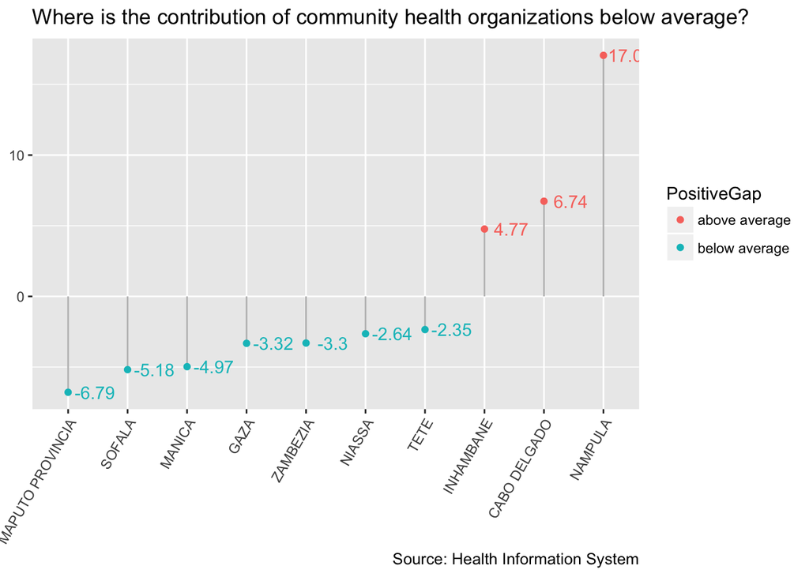

```r
base = ggplot(OrderedLoliToPlot, aes(province,gap,color=PositiveGap,
                              label = round(gap,2)))
lolliplot1 = base + geom_segment(aes(y = 0,
                                   x = province,
                                   yend = gap,
                                   xend = province), color = "gray")
lolliplot2=lolliplot1 + geom_point()
lolliplot3= lolliplot2 + scale_x_discrete(limits=OrderedLoliToPlot$province)

lolliplot5 = lolliplot3 + geom_text(nudge_x=0.45, show.legend = FALSE)

lolliplot6 = lolliplot5 + labs(title=title_loli,
                     x =NULL,
                     y = NULL,
                     caption = source)

lolliplot7 = lolliplot6 + theme(axis.text.x = element_text(angle = 60, vjust = 1, hjust=1))


lolliplot7
```

#### Exercise 3 - Box Plot

Going back to using the Washington education data…create a data frame with highest grade offered in Washington schools

```r
BoxToPlot=as.data.frame(prop.table(table(eduwa$High.Grade)))
names(BoxToPlot)=c('grade','pct')
```

Misc elements like source, title, and labels:

```r
boxplot_title = "Distribution of Highest Grade Offered in Washington Schools"
source.text = 'Source: US Department of Education'

#labels
ordLabels= levels(eduwa$High.Grade)
```

Create plot

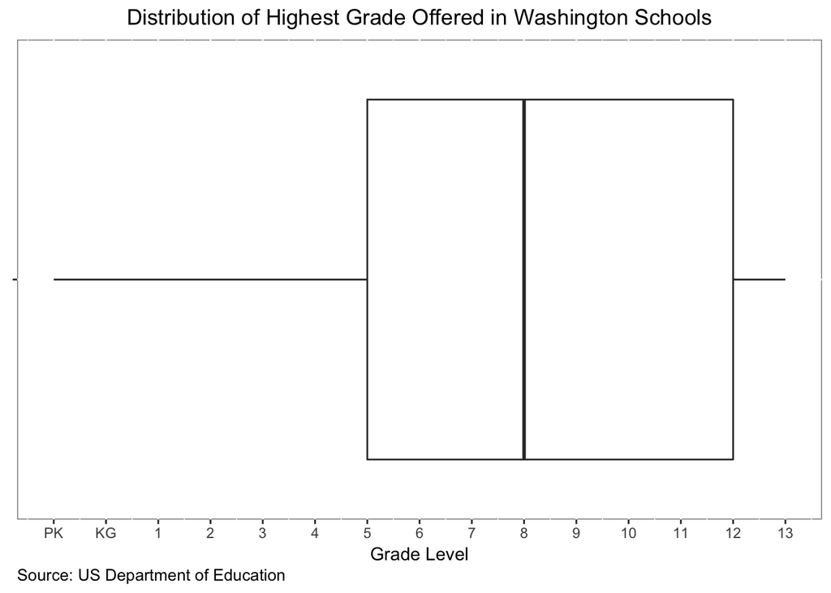

```r
box1 = ggplot(eduwa, aes(y=as.numeric(High.Grade), x=''))
box1 = box1 + geom_boxplot() + coord_flip()

box2 = box1 + scale_y_continuous(labels=ordLabels,breaks=1:15)

box3=box2 + labs(title=boxplot_title,
                     x =NULL,
                     y = 'Grade Level',
                     caption = source.text)

box4 = box3 + theme(panel.background = element_rect(fill = "white",
                                                    colour = "grey50"),
                    plot.title = element_text(hjust = 0.5),
                    plot.caption = element_text(hjust=0))
box4
```

#### Exercise 4 - Histogram

Now I make a histogram for the variable FREE LUNCH from the washington education data. First I create a data frame for ggplot to plot using only complete cases

```r
eduwa3=eduwa[complete.cases(eduwa$Free.Lunch),] #getting rid of missings
```

Misc elements: title

```r
hist.title = "Histogram of Number of Students Served Free Lunch in Washington Schools"
```

Create Plot

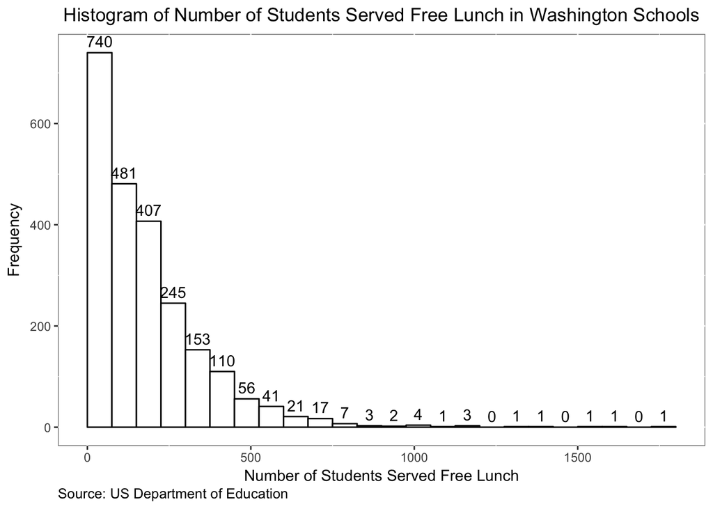

```r
base= ggplot(eduwa3,aes(x = Free.Lunch))
h1= base + geom_histogram(color="black", fill="white", binwidth = 75,boundary=0) #changing width
h2= h1 + stat_bin(binwidth = 75, aes(label=..count..),
                  geom = "text",boundary = 0,vjust=-0.5)

h3 = h2 + theme(panel.background = element_rect(fill = "white",
                                                    colour = "grey50"),
                    plot.title = element_text(hjust = 0.5),
                    plot.caption = element_text(hjust=0)) + labs(title=hist.title,
                     x ="Number of Students Served Free Lunch",
                     y = "Frequency",
                     caption = source.text)

h3
```

#### Exercise 5 - Histogram and density plot of student teacher ratio

First I create the data frame with the necessary variables (mean student teacher ratio by county)

```r
eduwa4=eduwa[complete.cases(eduwa$Student.Teacher.Ratio),]

eduwa5=as.data.frame(tapply(eduwa4$Student.Teacher.Ratio,
       eduwa4$County,
       mean))
names(eduwa5)=c('Student.Teacher.Ratio')
```

Misc elements:title

```r
hist.title2 = "Histogram of Average Student Teacher Ratios in Washington Counties"
```

Create Plot (Histogram)

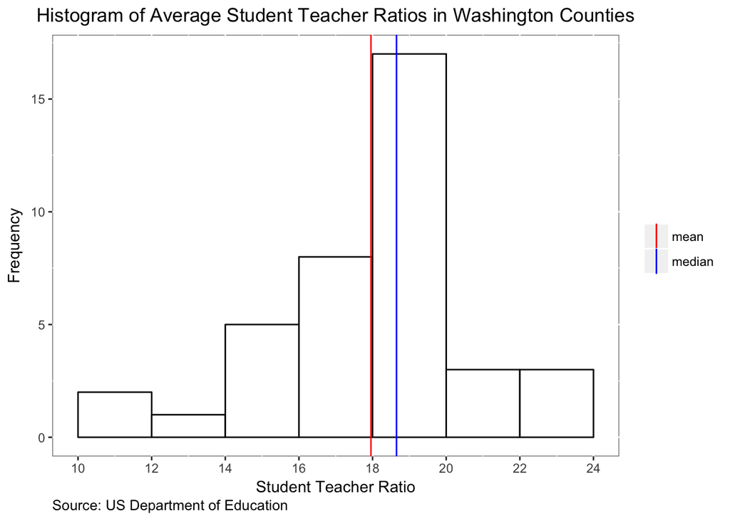

```r
base = ggplot(eduwa5, aes(x=Student.Teacher.Ratio))

hist1 = base +  geom_histogram(color="black", fill="white", binwidth = 2 ,boundary=0)

hist2 = hist1 + theme(panel.background = element_rect(fill = "white",
                                                    colour = "grey50"),
                    plot.title = element_text(hjust = 0.5),
                    plot.caption = element_text(hjust=0)) + labs(title=hist.title2,
                     x ="Student Teacher Ratio",
                     y = "Frequency",
                     caption = source.text)
hist3 = hist2 + scale_x_continuous(breaks=seq(0,24,2)) #adding more tick marks on the x axis

hist4 = hist3 + scale_y_continuous(breaks=seq(0,20,5)) # tick marks on y axis

hist5 = hist4 + geom_vline(aes(xintercept = mean(eduwa5$Student.Teacher.Ratio),colour="mean"),
                           show.legend  = TRUE) +
                geom_vline(aes(xintercept = median(eduwa5$Student.Teacher.Ratio),colour="median"),
                           show.legend  = TRUE) +
                scale_color_manual(name = NULL,
                                   values = c(median = "blue", mean = "red"))
hist5
```

Misc elements: title

```r
density.title = "Density Plot of Average Student Teacher Ratios in Washington Counties"
```

Create Plot (Density Plot)

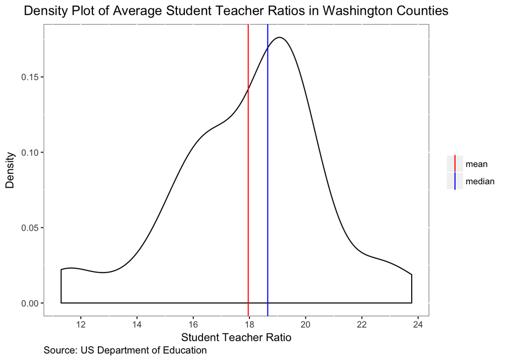

```r
den1 = base + geom_density(color="black", fill="white")

den2 = den1 + theme(panel.background = element_rect(fill = "white",
                                                    colour = "grey50"),
                    plot.title = element_text(hjust = 0.5),
                    plot.caption = element_text(hjust=0)) + labs(title=density.title,
                     x ="Student Teacher Ratio",
                     y = "Density",
                     caption = source.text)

den3 = den2 + scale_x_continuous(breaks=seq(0,24,2))

den4 = den3 + geom_vline(aes(xintercept = mean(eduwa5$Student.Teacher.Ratio),colour="mean"),
                           show.legend  = TRUE) +
                geom_vline(aes(xintercept = median(eduwa5$Student.Teacher.Ratio),colour="median"),
                           show.legend  = TRUE) +
                scale_color_manual(name = NULL,
                                   values = c(median = "blue", mean = "red"))

den4
```